[figure not shown]

## **1. Cây và các tính chất cơ bản của cây**

## **2. Cây khung của đồ thị**

# 1. Cây và các tính chất cơ bản của cây

**Định nghĩa:**

Cây là một đồ thị vô hướng, liên thông không có chu trình.

Rừng là đồ thị mà mỗi thành phần liên thông của nó là một cây.

[figure not shown]

$G_1, G_2$ là cây; $G_3,G_4$ không là cây.

**Định lí:** Giả sử $G=(V,E)$ là đồ thị vô hướng $n$ đỉnh. Khi đó những khẳng định sau là tương đương:

$G$ là một cây

$G$ không có chu trình và có $n-1$ cạnh

$G$ liên thông và có đúng $n-1$ cạnh

$G$ liên thông và mỗi cạnh của nó đều là cầu

Giữa hai đỉnh bất kỳ của $G$ được nối với nhau bởi đúng một đường đi đơn

$G$ không chứa chu trình nhưng nếu thêm vào nó một cạnh ta thu được đúng một chu trình

# 2. Cây khung của đồ thị

**Định nghĩa:** Giả sử $G=(V,E)$ là đồ thị vô hướng liên thông. Cây $T=(V,F)$ với $F\subset E$ được gọi là cây khung của đồ thị $G$.

[figure not shown]

$G$ và 2 cây khung $T_1$ và $T_2$

**Định lí (Cayley):** Số lượng cây khung của đồ thị đầy đủ $K_n$ (số cạnh $C^2_n$) là $n^{n-2}$.

[figure not shown]

**Bài toán 1:** Cho đồ thị vô hướng $G=(V,E)$. Hãy xây dựng một cây khung của đồ thị bắt đầu tại đỉnh $u\in V$

**Bài toán 2:** Cho đồ thị vô hướng $G=(V,E)$ có trọng số. Hãy xây dựng cây khung có độ dài nhỏ nhất.

### 2.1. Bài toán xây dựng cây khung (BFS hoặc DFS)

### 2.2. Bài toán cây khung nhỏ nhất

Để giải bài toán cây khung nhỏ nhất, chúng ta có thể liệt kê toàn bộ cây khung và chọn trong số đó một cây nhỏ nhất. Phương án như vậy thực sự không khả thi vì số cây khung của đồ thị là rất lớn cỡ $n^{n-2}$ (Định lí Caley)

**Định nghĩa:** Cho $G=(V,E)$ là đơn đồ thị vô hướng liên thông gồm $n$ đỉnh và có trọng số cạnh. Cây khung nhỏ nhất của $G$ là cây khung có tổng trọng số nhỏ nhất.

[figure not shown]

**Ví dụ:**

Một mạng gồm $n$ máy tính được đánh số từ $1, 2,\cdots, n$. Biết chi phí nối máy $i$ với máy $j$ là $c[i, j]$, $i, j = 1, 2,\cdots, n$. Hãy tìm cách nối mạng sao cho chi phí là nhỏ nhất.

Giả sử ta muốn xây dựng một hệ thống cáp viễn thông nối $n$ điểm của một mạng viễn thông sao cho điểm bất kỳ nào trong mạng đều có đường truyền tin tới các điểm khác. Biết chi phí xây dựng hệ thống cáp từ điểm $i$ đến điểm $j$ là $c[i,j]$. Hãy tìm cách xây dựng hệ thống mạng cáp sao cho chi phí là nhỏ nhất.

Giả sử ta muốn xây dựng một hệ thống đường sắt nối $n$ thành phố sao cho hành khách có thể đi lại giữa hai thành phố bất kỳ đồng thời tổng chi phí xây dựng phải là nhỏ nhất.

**Ý tưởng:**

- Khởi tạo: $A=\emptyset$ //Tập các cạnh của cây khung
- **while** $A$ chưa là cây khung ($|A|<n-1$)
  - tìm cạnh $(u,v)$ là cạnh *an toàn* đối với $A$ (an toàn: cạnh có trọng số nhỏ nhất và không biến $A$ thành chu trình)
  - $A=A\cup (u,v)$
- Kết quả: tập $A$

### a) Thuật toán Kruskal

- B1: Khởi tạo
  - $T = \emptyset$ *Khởi tạo tập cạnh cây khung là $\emptyset$.*
  - $d(H) = 0$ *Khởi tạo độ dài nhỏ nhất cây khung là 0.*
- B2: Sắp xếp các cạnh của đồ thị theo thứ tự tăng dần của trọng số.
- B3: Lặp
  - **while** $|T| < n - 1$ và $E \neq \emptyset$
    - $e$ = <Cạnh có độ dài nhỏ nhất>;
    - $E = E \setminus \{e\}$; // Loại cạnh e ra khỏi đồ thị
    - **if** $T \cup \{e\}$ không tạo nên chu trình
      - $T = T \cup \{e\}$; // Kết nạp e vào tập cạnh cây khung
      - $d(H) = d(H) + d(e)$; // Độ dài của tập cạnh cây khung
- B4: Kết quả
  - **if** $|T| < n-1$: <Đồ thị không liên thông>;
  - **else** return($T, d(H)$);
- Có 2 cách dừng vòng lặp khi xây dựng cây khung: hoặc số cạnh bằng $n-1$ hoặc số đỉnh bằng $n$
- Thời gian sắp xếp theo thứ tự tăng dần, ở đây có $m$ cạnh thì thời gian là $O(m\log m)$
- Làm thế nào để kiểm tra khi nhập cạnh $e$ vào thì ko làm xuất hiện chu trình: ta sử dụng phương pháp đánh dấu như sau, mỗi thành phần liên thông sẽ có 1 nhãn riêng (ban đầu bao nhiêu đỉnh thì có bấy nhiêu nhãn), khi nối cặp đỉnh đầu tiên thì chọn nhãn đại diện là của đỉnh đc sắp trước trong dữ liệu đồ thị, và khi nối các thành phần liên thông thì ưu tiên nhãn cho thành phần nào có nhiều đỉnh hơn (dùng rank để biết nhãn nào có nhiều đỉnh hơn), nếu lần nối nào đó mà 2 đỉnh có cùng nhãn thì khi đó sẽ tạo chu trình và ko thể nối đc.

| $T=\emptyset$, $\|T\|=0<6$ $d(H)=0$ | $T=\{(b,c)\}$, $\|T\|=1<6$ $d(H)=1$ |
| --- | --- |

| $T=\{(b,c);(d,e)\}$, $\|T\|=2<6$ $d(H)=1+1=2$ | $T=\{(b,c);(d,e);(a,b)\}$, $\|T\|=3<6$ $d(H)=2+2=4$ |
| --- | --- |

| $T=\{(b,c);(d,e);(a,b);(a,f)\}$, $\|T\|=4<6$ $d(H)=4+2=6$ | $T=\{(b,c);(d,e);(a,b);(a,f);(b,e)\}$, $\|T\|=5<6$ $d(H)=6+3=9$ |
| --- | --- |

| $T=\{(b,c);(d,e);(a,b);(a,f);(b,e)\}$, $\|T\|=5<6$ $d(H)=6+3=9$ | $T=\{(b,c);(d,e);(a,b);(a,f);(b,e);(d,g)\}$, $\|T\|=6$ $d(H)=9+5=14$ |
| --- | --- |

[figure not shown]

[output not shown]

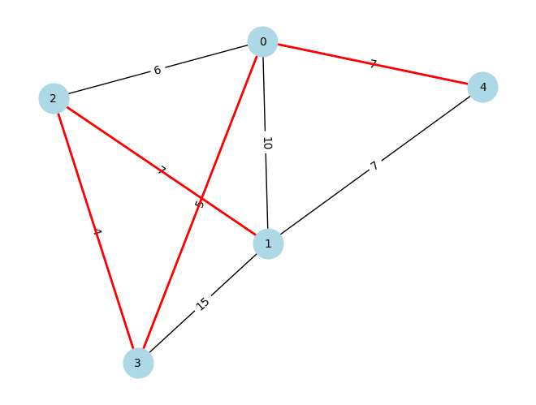

```python
import networkx as nx
import matplotlib.pyplot as plt

def create_graph_from_adjacency_matrix(matrix): # Khởi tạo đồ thị từ ma trận kề
    vertices = len(matrix)
    graph = {"vertices": vertices, "edges": []}
    for i in range(vertices):
        for j in range(i + 1, vertices):
            if matrix[i][j] != 0:  # Nếu có cạnh giữa đỉnh i và j
                graph["edges"].append((matrix[i][j], i, j))
    return graph
def find(parent, i): # Tìm đại diện của tập hợp chứa đỉnh i
    while parent[i] != i:
        i = parent[i]
    return i

def union(parent, rank, x, y): # Hợp hai tập hợp chứa x và y
    root_x = find(parent, x)
    root_y = find(parent, y)
    if rank[root_x] < rank[root_y]:
        parent[root_x] = root_y
    elif rank[root_x] > rank[root_y]:
        parent[root_y] = root_x
    else:
        parent[root_y] = root_x
        rank[root_x] += 1

def kruskal(graph):  # Thuật toán Kruskal
    T = []  # Cây khung nhỏ nhất
    total_weight = 0  # Tổng trọng số của cây khung
    graph["edges"].sort() # Sắp xếp các cạnh theo thứ tự tăng dần của trọng số
    parent = []
    rank = []
    for node in range(graph["vertices"]):  # Khởi tạo tập hợp rời rạc cho mỗi đỉnh
        parent.append(node)
        rank.append(0)
    for weight, u, v in graph["edges"]:  # Duyệt qua các cạnh
        if len(T) == graph["vertices"] - 1:
            break
        root_u = find(parent, u)
        root_v = find(parent, v)
        print("chọn root_u, root_v ",root_u," và ",root_v)
        if root_u != root_v:  # Nếu thêm cạnh không tạo chu trình, kết nạp cạnh đó vào cây khung
            T.append((u, v, weight))
            print("T đây nhé ",T)
            total_weight += weight
            print("Trọng số: ", total_weight)
            union(parent, rank, root_u, root_v)
            print("Thông tin sau khi chạy hàm union gồm rank ", rank, " và ", parent)
    if len(T) != graph["vertices"] - 1:  # Trả lại kết quả
        return "Đồ thị không liên thông"
    else:
        return T, total_weight

def draw_graph(adjacency_matrix, mst_edges=None):  # Vẽ đồ thị
    G = nx.Graph()
    for i in range(len(adjacency_matrix)):  # Thêm các cạnh vào đồ thị
        for j in range(i + 1, len(adjacency_matrix)):
            if adjacency_matrix[i][j] != 0:
                G.add_edge(i, j, weight=adjacency_matrix[i][j])
    pos = nx.spring_layout(G)  # Bố trí các đỉnh
    nx.draw(G, pos, with_labels=True, node_color='lightblue', node_size=700, font_size=10)
    labels = nx.get_edge_attributes(G, 'weight')
    nx.draw_networkx_edge_labels(G, pos, edge_labels=labels)

    if mst_edges:  # Nếu có cây khung nhỏ nhất, vẽ nó nổi bật
        mst_edges = [(u, v) for u, v, w in mst_edges]
        nx.draw_networkx_edges(G, pos, edgelist=mst_edges, edge_color='red', width=2)
    plt.show()

adjacency_matrix = [[0, 10, 6, 5, 7],
                    [10, 0, 7, 15, 7],
                    [6, 7, 0, 4, 0],
                    [5, 15, 4, 0, 0],
                    [7, 7, 0, 0, 0]]

graph = create_graph_from_adjacency_matrix(adjacency_matrix)# Tạo đồ thị từ ma trận kề
# print(graph)
# graph["edges"].sort()
# print(graph)

result = kruskal(graph) # Chạy thuật toán Kruskal
if mst:
    print("Cây khung nhỏ nhất:")
    for u, v, weight in mst:
        print(f"Cạnh từ {u} đến {v} với trọng số {weight}")
    print(f"Tổng trọng số: {total_weight_or_error}")
    draw_graph(adjacency_matrix, mst)
else:
    print(total_weight_or_error)
    draw_graph(adjacency_matrix)
```

### Giải thích đoạn mã này

```
for node in range(graph["vertices"]):
        parent.append(node)
        rank.append(0)
```

#### 1. Mục đích

- Đoạn mã này khởi tạo hai danh sách `parent` và `rank` cho các đỉnh của đồ thị.
- Đây là bước chuẩn bị để thực hiện thuật toán Kruskal sử dụng cấu trúc dữ liệu Disjoint Set (hay Union-Find).

#### 2. Ý nghĩa các biến

- **`parent`**: Lưu đại diện của tập hợp mà mỗi đỉnh thuộc về.
  - Ban đầu, mỗi đỉnh là một tập hợp riêng biệt.
  - Giá trị `parent[node] = node` nghĩa là mỗi đỉnh tự nó là đại diện của chính nó.
- **`rank`**: Lưu độ sâu (rank) của mỗi cây trong Disjoint Set.
  - Ban đầu, tất cả các cây có độ sâu là 0.

#### 3. Hoạt động trong vòng lặp

- **`range(graph["vertices"])`**: Lặp qua tất cả các đỉnh của đồ thị (giả định rằng số lượng đỉnh được lưu trong `graph["vertices"]`).
- **`parent.append(node)`**: Đặt mỗi đỉnh làm đại diện ban đầu của tập hợp riêng của nó.
- **`rank.append(0)`**: Gán độ sâu ban đầu của mỗi tập hợp là 0.

#### 4. Ví dụ

Giả sử đồ thị có 4 đỉnh ((n = 4)):

- **Trước vòng lặp**:
  - `parent = []`
  - `rank = []`
- **Sau vòng lặp**:
  - `parent = [0, 1, 2, 3]` (mỗi đỉnh là đại diện của chính nó).
  - `rank = [0, 0, 0, 0]` (tất cả các tập hợp có độ sâu ban đầu là 0).

#### 5. Tại sao cần `parent` và `rank`?

- **`parent`**: Để theo dõi đại diện của tập hợp trong thuật toán Union-Find.
- **`rank`**: Để tối ưu hóa khi hợp nhất hai tập hợp, đảm bảo rằng cây đại diện không trở nên quá sâu, giúp giảm thời gian tìm kiếm (tối ưu hóa theo rank).

### b) Thuật toán Prim

- B1: Khởi tạo
  - $V_H = \{s\}$ //Tập đỉnh cây khung thiết lập ban đầu là $s$ bất kì
  - $V = V\setminus\{s\}$ //Tập đỉnh $V$ được bớt đi $s$
  - $T = \emptyset$ và $d(H) = 0$
- B2: Lặp
  - **while** $V\neq\emptyset$
    - $e = (u, v)$ // cạnh có độ dài nhỏ nhất thỏa mãn $u\in V$, $v\in V_H$
    - $d(H) = d(H) + d(e)$ // Thiết lập độ dài cây khung nhỏ nhất
    - $T = T \cup \{e\}$ // Kết nạp $e$ vào cây khung
    - $V = V \setminus\{u\}$ // Tập đỉnh $V$ bớt đi đỉnh $u$
    - $V_H = V_H\cup \{u\}$ // Tập đỉnh $V_H$ thêm vào đỉnh $u$
- B3: Kết quả:
  - **if** $|T|<n-1$: <Đồ thị không liên thông>;
  - **else** return($T, d(H)$)

| $V_H=\{g\}$, $V=\{a,b,c,d,e,f\}\neq \emptyset$ $T=\emptyset$, $\|T\|=0$ | $V_H=\{g,d\}$, $V=\{a,b,c,e,f\}\neq \emptyset$ $T=\{(g,d)\}$, $\|T\|=1$ |
| --- | --- |

| $V_H=\{g,d,e\}$, $V=\{a,b,c,f\}\neq \emptyset$ $T=\{(g,d); (d,e)\}$, $\|T\|=2$ | $V_H=\{g,d,e,b\}$, $V=\{a,c,f\}\neq \emptyset$ $T=\{(g,d); (d,e); (e,b)\}$, $\|T\|=3$ |
| --- | --- |

| $V_H=\{g,d,e,b,c\}$, $V=\{a,f\}\neq \emptyset$ $T=\{(g,d); (d,e); (e,b); (b,c)\}$, $\|T\|=4$ | $V_H=\{g,d,e,b,c,a\}$, $V=\{f\}\neq \emptyset$ $T=\{(g,d); (d,e); (e,b); (b,c); (b,a)\}$, $\|T\|=5$ |
| --- | --- |

| $V_H=\{g,d,e,b,c,a,f\}$, $V=\emptyset$ $T=\{(g,d); (d,e); (e,b); (b,c); (b,a); (a,f)\}$, $\|T\|=6$ | $V_H=\{a\}$, $V=\{b,c,d,e,f,g\}\neq \emptyset$ $T=\emptyset$, $\|T\|=0$ |
| --- | --- |

### b) Thuật toán Prim cải tiến

| Bước lặp | Đỉnh chọn | $a$ | $b$ | $c$ | $d$ | $e$ | $f$ | $g$ | $T$ |
| --- | --- | --- | --- | --- | --- | --- | --- | --- | --- |
| 1 | $a$ | $-$ | $[a,2]^*$ | $[a,\infty]$ | $[a,7]$ | $[a,\infty]$ | $[a,2]$ | $[a,\infty]$ | $\emptyset$ |
| 2 | $b$ |  | $-$ | $[b,1]^*$ | $[b,4]$ | $[b,3]$ | $[a,2]$ | $[a,\infty]$ | $(a,b)$ |
| 3 | $c$ |  |  | $-$ | $[b,4]$ | $[b,3]$ | $[a,2]^*$ | $[a,\infty]$ | $(b,c)$ |
| 4 | $f$ |  |  |  | $[b,4]$ | $[b,3]^*$ | $-$ | $[a,\infty]$ | $(a,f)$ |
| 5 | $e$ |  |  |  | $[e,1]^*$ | $-$ |  | $[e,7]$ | $(b,e)$ |
| 6 | $d$ |  |  |  | $-$ |  |  | $[d,5]^*$ | $(e,d)$ |
| 7 | $g$ |  |  |  |  |  |  | $-$ | $(d,g)$ |

[output not shown]

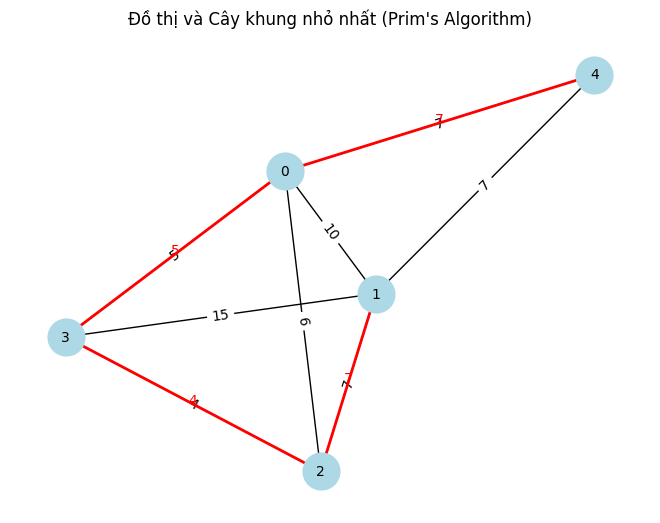

```python
#code cải tiến, cập nhật khoảng cách từ các đỉnh đên cây khung
import networkx as nx
import matplotlib.pyplot as plt

def prims_algorithm(adj_matrix, start):
    total_weight = 0
    while len(T) < n - 1:  # Cần n-1 cạnh để tạo cây khung
        min_edge = None
        min_weight = float('inf')
        for u in range(n):  # Tìm cạnh nhỏ nhất từ các đỉnh đã thăm
            if visited[u]:
                for v in range(n):
                    if not visited[v] and 0 < adj_matrix[u][v] < min_weight:
                        min_edge = (u, v)
                        min_weight = adj_matrix[u][v]
        if min_edge is None:  # Nếu không tìm thấy cạnh hợp lệ, đồ thị không liên thông
            return None, "Đồ thị không liên thông"
        u, v = min_edge  # Cập nhật cây khung
        T.append((u, v, min_weight))
        total_weight += min_weight
        visited[v] = True  # Đánh dấu đỉnh mới đã thăm
    return T, total_weight

def draw_graph_with_mst(adj_matrix, mst_edges):
    G = nx.Graph()
    n = len(adj_matrix)
    for i in range(n):
        for j in range(i + 1, n):
            if adj_matrix[i][j] > 0:
                G.add_edge(i, j, weight=adj_matrix[i][j])

    pos = nx.spring_layout(G)  # Vị trí các đỉnh
    nx.draw(G, pos, with_labels=True, node_color='lightblue', node_size=700, font_size=10)
    labels = nx.get_edge_attributes(G, 'weight')
    nx.draw_networkx_edge_labels(G, pos, edge_labels=labels)
    if mst_edges:
        nx.draw_networkx_edges(G, pos, edgelist=[(u, v) for u, v, _ in mst_edges], edge_color='red', width=2)
        for u, v, weight in mst_edges:
            x, y = (pos[u] + pos[v]) / 2
            plt.text(x, y, f'{weight}', color='red', fontsize=10, ha='center')
    plt.title("Đồ thị và Cây khung nhỏ nhất (Prim's Algorithm)")
    plt.show()

adj_matrix = [[0, 10, 6, 5, 7],
                    [10, 0, 7, 15, 7],
                    [6, 7, 0, 4, 0],
                    [5, 15, 4, 0, 0],
                    [7, 7, 0, 0, 0]]

start = 0
n = len(adj_matrix)  # Số đỉnh trong đồ thị
visited = [False] * n  # Danh sách đánh dấu các đỉnh đã thăm
visited[start] = True  # Đánh dấu đỉnh bắt đầu
T = []  # Tập cạnh cây khung
result = prims_algorithm(adj_matrix, start_node)
if result[0] is not None:
    mst_edges, total_weight = result
    print("Cây khung nhỏ nhất:")
    for u, v, weight in mst_edges:
        print(f"Cạnh từ {u} đến {v} với trọng số {weight}")
    print(f"Tổng trọng số: {total_weight}")
    draw_graph_with_mst(adj_matrix, mst_edges)
else:
    print(result[1])
```

```python
def prim_mst(graph):
    n = len(graph)
    mst_edges = []  # Danh sách các cạnh của cây khung nhỏ nhất
    selected = [False] * n  # Theo dõi các đỉnh đã thêm vào cây khung
    min_edge = [float('inf')] * n  # Trọng số nhỏ nhất tới mỗi đỉnh
    near = [-1] * n  # Đỉnh gần nhất cho mỗi đỉnh
    min_edge[0] = 0  # Bắt đầu từ đỉnh 0
    near[0] = 0
    for _ in range(n):
        u = -1  # Tìm đỉnh u với trọng số nhỏ nhất trong min_edge mà chưa được chọn
        for i in range(n):
            if not selected[i] and (u == -1 or min_edge[i] < min_edge[u]):
                u = i
        if u == -1:  # Không tìm được đỉnh hợp lệ
            print("Đồ thị không liên thông.")
            return []

        selected[u] = True # Thêm đỉnh u vào cây khung
        if near[u] != u:  # Tránh thêm cạnh từ chính nó
            # Tăng chỉ số đỉnh lên 1 khi lưu kết quả
            mst_edges.append((near[u] + 1, u + 1, graph[near[u]][u]))
        for v in range(n): # Cập nhật trọng số và đỉnh gần nhất
            if not selected[v] and graph[u][v] < min_edge[v]:
                min_edge[v] = graph[u][v]
                near[v] = u
    return mst_edges

INF = float('inf')
graph = [
    [0, 2, 3, INF, INF, INF, INF, INF],
    [2, 0, 15, 2, INF, INF, INF, INF],
    [3, 15, 0, 13, 5, INF, INF, INF],
    [INF, 2, 13, 0, 9, INF, INF, INF],
    [INF, INF, 5, 9, 0, 7, INF, INF],
    [INF, INF, INF, INF, 7, 0, 4, 6],
    [INF, INF, INF, INF, INF, 4, 0, 2],
    [INF, INF, INF, INF, INF, 6, 2, 0],
]
mst = prim_mst(graph)
if mst:
    print("Cây khung nhỏ nhất (MST):")
    for u, v, weight in mst:
        print(f"({u}, {v}) - Trọng số: {weight}")
else:
    print("Không thể tìm cây khung nhỏ nhất.")
```

```
Cây khung nhỏ nhất (MST):
(1, 2) - Trọng số: 2
(2, 4) - Trọng số: 2
(1, 3) - Trọng số: 3
(3, 5) - Trọng số: 5
(5, 6) - Trọng số: 7
(6, 7) - Trọng số: 4
(7, 8) - Trọng số: 2
```